# Machine Learning: AllLife Bank Personal Loan Campaign

## Problem Statement

### Context

AllLife Bank is a US bank that has a growing customer base. The majority of these customers are liability customers (depositors) with varying sizes of deposits. The number of customers who are also borrowers (asset customers) is quite small, and the bank is interested in expanding this base rapidly to bring in more loan business and in the process, earn more through the interest on loans. In particular, the management wants to explore ways of converting its liability customers to personal loan customers (while retaining them as depositors).

A campaign that the bank ran last year for liability customers showed a healthy conversion rate of over 9% success. This has encouraged the retail marketing department to devise campaigns with better target marketing to increase the success ratio.

You as a Data scientist at AllLife bank have to build a model that will help the marketing department to identify the potential customers who have a higher probability of purchasing the loan.

### Objective

To predict whether a liability customer will buy personal loans, to understand which customer attributes are most significant in driving purchases, and identify which segment of customers to target more.

### Data Dictionary

- `ID`: Customer ID
- `Age`: Customer’s age in completed years
- `Experience`: #years of professional experience
- `Income`: Annual income of the customer (in thousand dollars)
- `ZIP Code`: Home Address ZIP code.
- `Family`: the Family size of the customer
- `CCAvg`: Average spending on credit cards per month (in thousand dollars)
- `Education`: Education Level. 1: Undergrad; 2: Graduate;3: Advanced/Professional
- `Mortgage`: Value of house mortgage if any. (in thousand dollars)
- `Personal_Loan`: Did this customer accept the personal loan offered in the last campaign? (0: No, 1: Yes)
- `Securities_Account`: Does the customer have securities account with the bank? (0: No, 1: Yes)
- `CD_Account`: Does the customer have a certificate of deposit (CD) account with the bank? (0: No, 1: Yes)
- `Online`: Do customers use internet banking facilities? (0: No, 1: Yes)
- `CreditCard`: Does the customer use a credit card issued by any other Bank (excluding All life Bank)? (0: No, 1: Yes)

## Importing necessary libraries

```python
# Installing the libraries with the specified version.
!pip install numpy==1.25.2 pandas==1.5.3 matplotlib==3.7.1 seaborn==0.13.1 scikit-learn==1.2.2 sklearn-pandas==2.2.0 -q --user
```

[output not shown]

```python
from google.colab import drive
drive.mount('/content/drive')
```

**Note**: *After running the above cell, kindly restart the notebook kernel and run all cells sequentially from the start again.*

```python
import pandas as pd
import numpy as np

import matplotlib.pylab as plt
%matplotlib inline

import seaborn as sns
from sklearn.model_selection  import train_test_split
from sklearn.cluster import KMeans

from scipy.stats import zscore

from sklearn import metrics
import matplotlib.pyplot as plt

from sklearn.tree import DecisionTreeClassifier
from sklearn import tree
```

## Loading the dataset

```python
df = pd.read_csv("/content/drive/MyDrive/Colab Notebooks/Loan_Modelling.csv")
```

## Data Overview

- Observations
- Sanity checks

```python
# Viewing the first 5 rows of the dataset
df.head()
```

[output not shown]

```python
# Viewing the last 5 rows of the dataset
df.tail()
```

|  | ID | Age | Experience | Income | ZIPCode | Family | CCAvg | Education | Mortgage | Personal_Loan | Securities_Account | CD_Account | Online | CreditCard |
| --- | --- | --- | --- | --- | --- | --- | --- | --- | --- | --- | --- | --- | --- | --- |
| 4995 | 4996 | 29 | 3 | 40 | 92697 | 1 | 1.9 | 3 | 0 | 0 | 0 | 0 | 1 | 0 |
| 4996 | 4997 | 30 | 4 | 15 | 92037 | 4 | 0.4 | 1 | 85 | 0 | 0 | 0 | 1 | 0 |
| 4997 | 4998 | 63 | 39 | 24 | 93023 | 2 | 0.3 | 3 | 0 | 0 | 0 | 0 | 0 | 0 |
| 4998 | 4999 | 65 | 40 | 49 | 90034 | 3 | 0.5 | 2 | 0 | 0 | 0 | 0 | 1 | 0 |
| 4999 | 5000 | 28 | 4 | 83 | 92612 | 3 | 0.8 | 1 | 0 | 0 | 0 | 0 | 1 | 1 |

```python
# Checking the shape of the data
df.shape
```

```
(5000, 14)
```

The data has 5000 rows and 14 columns

```python
# Checking the data types of the columns in the dataset
df.info()
```

```
<class 'pandas.core.frame.DataFrame'>
RangeIndex: 5000 entries, 0 to 4999
Data columns (total 14 columns):
 #   Column              Non-Null Count  Dtype
---  ------              --------------  -----
 0   ID                  5000 non-null   int64
 1   Age                 5000 non-null   int64
 2   Experience          5000 non-null   int64
 3   Income              5000 non-null   int64
 4   ZIPCode             5000 non-null   int64
 5   Family              5000 non-null   int64
 6   CCAvg               5000 non-null   float64
 7   Education           5000 non-null   int64
 8   Mortgage            5000 non-null   int64
 9   Personal_Loan       5000 non-null   int64
 10  Securities_Account  5000 non-null   int64
 11  CD_Account          5000 non-null   int64
 12  Online              5000 non-null   int64
 13  CreditCard          5000 non-null   int64
dtypes: float64(1), int64(13)
memory usage: 547.0 KB
```

```python
# Another check for missing values if any
df.isnull().sum()
```

```
ID                    0
Age                   0
Experience            0
Income                0
ZIPCode               0
Family                0
CCAvg                 0
Education             0
Mortgage              0
Personal_Loan         0
Securities_Account    0
CD_Account            0
Online                0
CreditCard            0
dtype: int64
```

As seen above, there is not any sign of missing values in any column in the data.

```python
# Checking for duplicated entries in the data.
df.duplicated().sum()
```

```
0
```

There is zero duplicated entries in the data.

```python
# Check the statistical summary of the data.
df.describe().T
```

|  | count | mean | std | min | 25% | 50% | 75% | max |
| --- | --- | --- | --- | --- | --- | --- | --- | --- |
| ID | 5000.0 | 2500.500000 | 1443.520003 | 1.0 | 1250.75 | 2500.5 | 3750.25 | 5000.0 |
| Age | 5000.0 | 45.338400 | 11.463166 | 23.0 | 35.00 | 45.0 | 55.00 | 67.0 |
| Experience | 5000.0 | 20.104600 | 11.467954 | -3.0 | 10.00 | 20.0 | 30.00 | 43.0 |
| Income | 5000.0 | 73.774200 | 46.033729 | 8.0 | 39.00 | 64.0 | 98.00 | 224.0 |
| ZIPCode | 5000.0 | 93169.257000 | 1759.455086 | 90005.0 | 91911.00 | 93437.0 | 94608.00 | 96651.0 |
| Family | 5000.0 | 2.396400 | 1.147663 | 1.0 | 1.00 | 2.0 | 3.00 | 4.0 |
| CCAvg | 5000.0 | 1.937938 | 1.747659 | 0.0 | 0.70 | 1.5 | 2.50 | 10.0 |
| Education | 5000.0 | 1.881000 | 0.839869 | 1.0 | 1.00 | 2.0 | 3.00 | 3.0 |
| Mortgage | 5000.0 | 56.498800 | 101.713802 | 0.0 | 0.00 | 0.0 | 101.00 | 635.0 |
| Personal_Loan | 5000.0 | 0.096000 | 0.294621 | 0.0 | 0.00 | 0.0 | 0.00 | 1.0 |
| Securities_Account | 5000.0 | 0.104400 | 0.305809 | 0.0 | 0.00 | 0.0 | 0.00 | 1.0 |
| CD_Account | 5000.0 | 0.060400 | 0.238250 | 0.0 | 0.00 | 0.0 | 0.00 | 1.0 |
| Online | 5000.0 | 0.596800 | 0.490589 | 0.0 | 0.00 | 1.0 | 1.00 | 1.0 |
| CreditCard | 5000.0 | 0.294000 | 0.455637 | 0.0 | 0.00 | 0.0 | 1.00 | 1.0 |

```python
# Checking the total number of unique values in the zipcode column
df['ZIPCode'].nunique()
```

```
467
```

- There is a total of 467 different zipcodes in the data. This indicates that the area in which the data is collected is quite large.

## Exploratory Data Analysis.

- EDA is an important part of any project involving data.
- It is important to investigate and understand the data better before building a model with it.
- A few questions have been mentioned below which will help you approach the analysis correctly and generate insights from the data.
- A thorough analysis of the data, in addition to the questions mentioned below, should be done.

**Questions**:

1. What is the distribution of mortgage attribute? Are there any noticeable patterns or outliers in the distribution?
2. How many customers have credit cards?
3. What are the attributes that have a strong correlation with the target attribute (personal loan)?
4. How does a customer's interest in purchasing a loan vary with their age?
5. How does a customer's interest in purchasing a loan vary with their education?

### Question 1

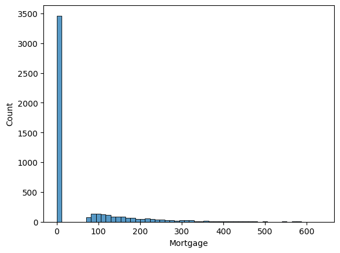

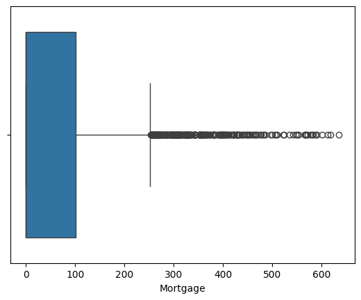

```python
sns.histplot(data=df,x='Mortgage')
plt.show()
sns.boxplot(data=df,x='Mortgage')
plt.show()
```

- The distribution is skewed towards the right as seen in the boxplot above.
- There are many outliers present in the Mortgage column, specifically from the value 250 and above following the 75% percentile whisker.

### Question 2

```python
# Check how many customers have a credit card in the data
df['CreditCard'].value_counts()
```

```
CreditCard
0    3530
1    1470
Name: count, dtype: int64
```

- 1470 customers use a credit card, this is much less than 50% of the total amount of customers. More than half the amount of customers do not use a credit card in the data.

### Question 3

```python
# Finding the attributes that have a strong correlation with the personal loan
df.corr()['Personal_Loan']
```

```
ID                   -0.024801
Age                  -0.007726
Experience           -0.007413
Income                0.502462
ZIPCode              -0.002974
Family                0.061367
CCAvg                 0.366889
Education             0.136722
Mortgage              0.142095
Personal_Loan         1.000000
Securities_Account    0.021954
CD_Account            0.316355
Online                0.006278
CreditCard            0.002802
Name: Personal_Loan, dtype: float64
```

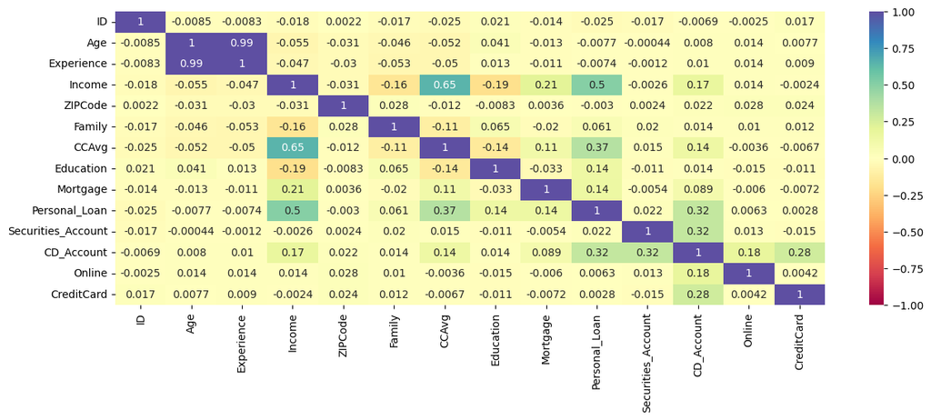

```python
plt.figure(figsize=(15,5))
sns.heatmap(df.corr(),annot=True,cmap='Spectral',vmin=-1,vmax=1)
plt.show()
```

- As seen in the above chart and visualization, the Income attribute contains the strongest correlation with the target attribute, personal loan.

### Question 4

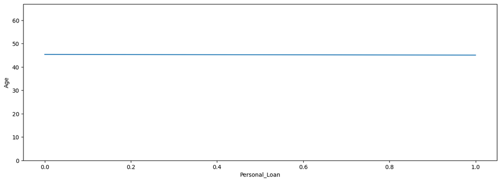

```python
# How does a customer's interest in purchasing a loan vary with their age?
import matplotlib.pyplot as plt
import seaborn as sns

plt.figure(figsize=(15, 5))
sns.lineplot(data=df, y='Age', x='Personal_Loan', ci=False);
plt.ylim(0, 67)
plt.show()
```

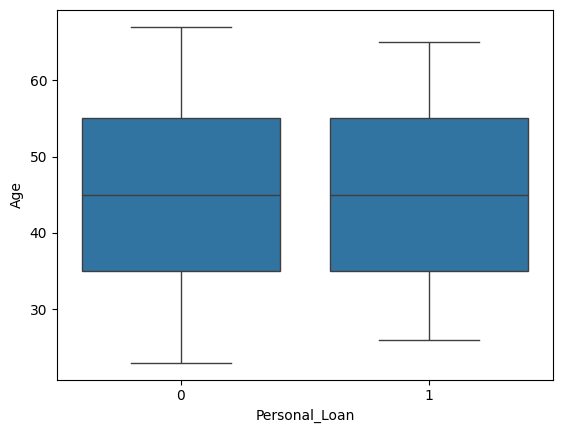

```python
sns.boxplot(data=df, y='Age', x='Personal_Loan') ;
```

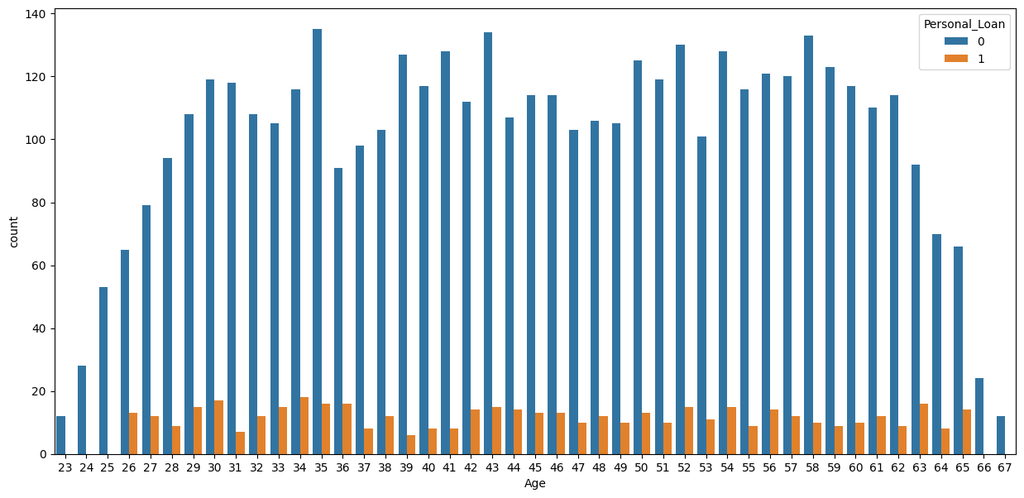

```python
plt.figure(figsize=(15,7))
sns.countplot(data=df, x='Age',hue='Personal_Loan')
```

- As seen in the above lineplot, boxplot, and countplot, there really is no association between the customers age in their decision for purchasing a loan, the data more or so is mostly a normal distribution.

### Question 5

[figure not shown]

```python
# How does a customer's interest in purchasing a loan vary with their education?
# Note: 1 = Undergrad, 2 = Graduate and 3 = Professional
plt.figure(figsize=(15,7))
sns.countplot(data=df, x='Education',hue='Personal_Loan')
```

- As seen in the above counterplot, both the graduates(2) and the professionals(3) have a much lower margin in denying the personal loan offer compared to the undergraduates(1).
- However, on the flip side, the graduates and the professionals had almost the same amount of accepted personal loans and the undergrads had half as much.
- This shows that as more advanced the educational level is, the more likely the personal offer will be accepted, and vice versa.

## Univariate Analysis

### Checking the distribution for numerical columns

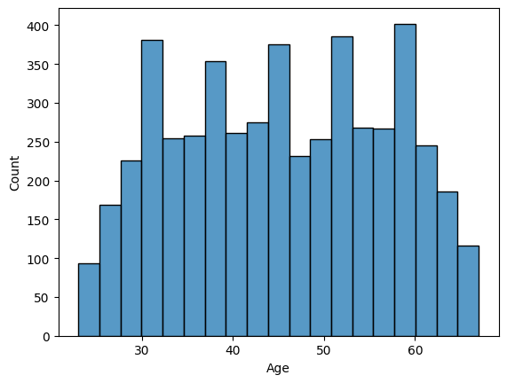

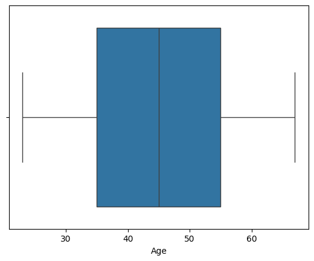

```python
# Observations for Age

sns.histplot(data=df,x='Age')
plt.show()
sns.boxplot(data=df,x='Age')
plt.show()
```

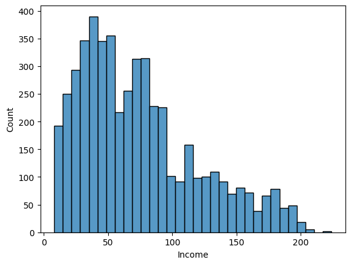

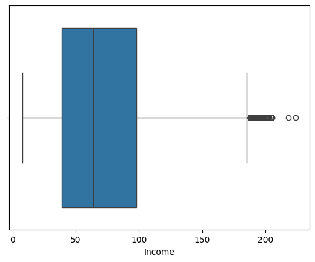

```python
# Observations on Income

sns.histplot(data=df,x='Income')
plt.show()
sns.boxplot(data=df,x='Income')
plt.show()
```

- As seen in the histogram and boxplot above, the annual income of the customers is skewed to the right.
- There are also many outliers present in the column.
- The income being right-skewed also means that the majority of the customers make less than 99,000 dollars, this can show the type of economic/financial situation most customers are in.

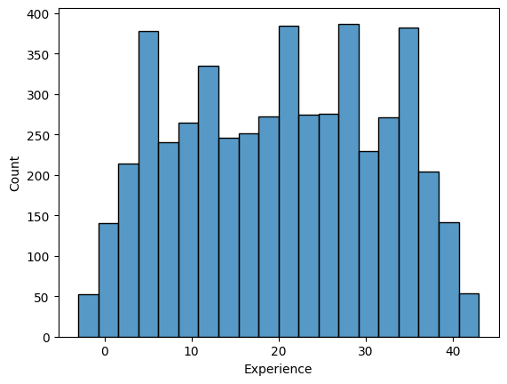

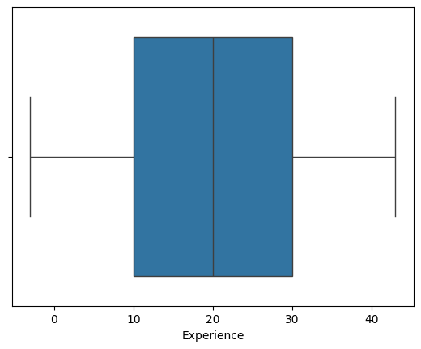

```python
# Observations on Experience

sns.histplot(data=df,x='Experience')
plt.show()
sns.boxplot(data=df,x='Experience')
plt.show()
```

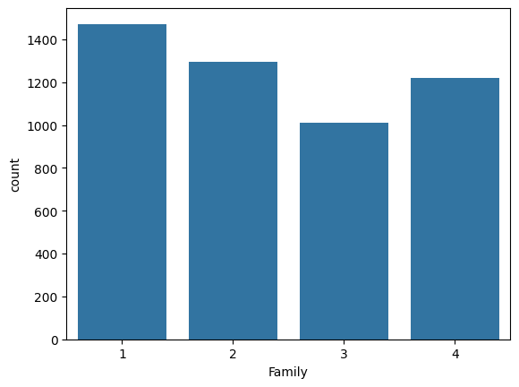

```python
# Observations on Family

sns.countplot(data=df,x='Family')
plt.show()
```

- In the counterplot above, the family sizes of the customers are not significantly different from each other.
- The greatest family size being 1 whilst the least family size being 3 indicates that the customers are most prone to smaller families in that demographic.

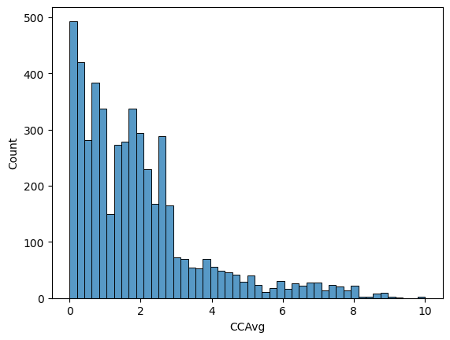

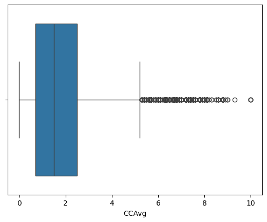

```python
# Observation on CCAVg

sns.histplot(data=df,x='CCAvg')
plt.show()
sns.boxplot(data=df,x='CCAvg')
plt.show()
```

- The average spending on credit cards per month for customers is highly skewed to the right. This indicates that there is a significant amount of customers who do not spend too much on credit cards per month.
- This can either be good or bad, in a good manner if the customers are saving their money wisely and in a bad way if they are not wealthy enough to spend money on certain things.
- There are also many outliers present after 5 thousand dollars spent.

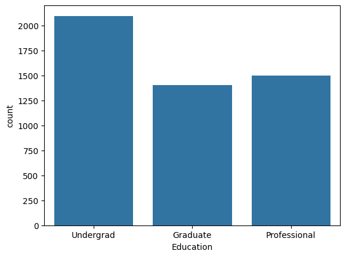

```python
# Observation on Education

# To make the depiction easier, convert 1 = Undergrad, 2 = Graduate and 3 = Professional
df['Education'] = df['Education'].replace({1:'Undergrad',2:'Graduate',3:'Professional'})

sns.countplot(data=df,x='Education')
plt.show()
```

- As seen in the counterplot above, there is a good margin for the amount of undergraduates collected in the data compared to graduates and professionals. This can suggest that the demographic in the data is mostly young individuals or those with not as much experience educational-wise.

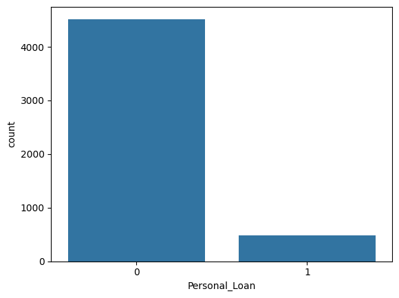

```python
# Observation on Personal Loan

sns.countplot(data=df,x='Personal_Loan')
plt.show()
```

- In the above count plot, there is a major difference in the amount of customers who had declined the personal loan offer compared to those who had accepted.
- This can suggest the type of customers who have been offered.

## Bivariate Analysis

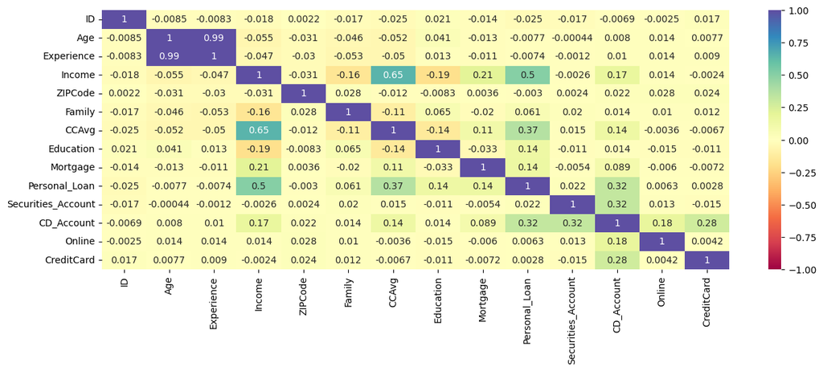

```python
# Creating a heat map to visualize the correlations of all the variables in the data

# First convert the Education variables back to its original state
df['Education'] = df['Education'].replace({'Undergrad':1,'Graduate':2,'Professional':3})

plt.figure(figsize=(15,5))
sns.heatmap(df.corr(),annot=True,cmap='Spectral',vmin=-1,vmax=1)
plt.show()
```

**Observations**

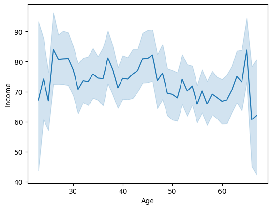

```python
# Exploring the correlation between Age and Income

sns.lineplot(data=df,x='Age',y='Income')
plt.show()
```

- As seen in the above line plot, there is not correlation between the two variables as there is no gradual increase or decrease in the lines.
- Although from ages 45 to 65 there does seem to be somewhat of a decrease in the customer's annual income. This can suggest that customers at that age do not have high-income jobs.

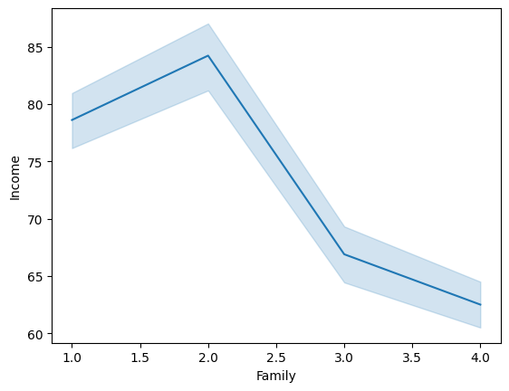

```python
# Finding the correlation between Family and Income

sns.lineplot(data=df,x='Family',y='Income')
plt.show()
```

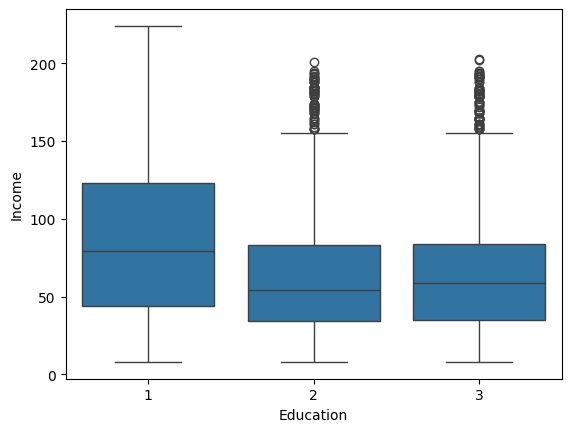

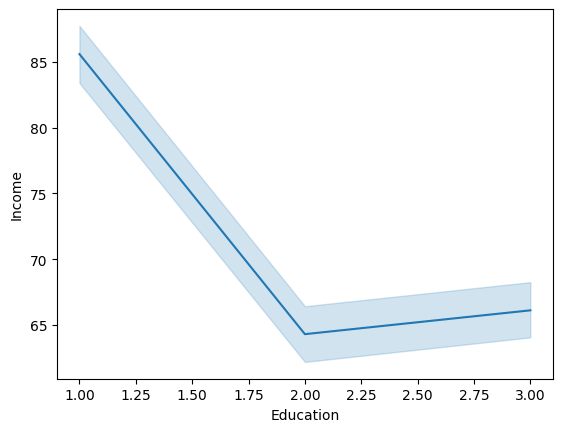

```python
# Finding the correlation between Income and Education

# Note: 1 = Undergrad, 2 = Graduate and 3 = Professional

sns.boxplot(data=df,y='Income',x='Education')
plt.show()
sns.lineplot(data=df,y='Income',x='Education')
plt.show()
```

- From the plots above, it is shown that undergraduates have the most amount of income compared to graduates and professionals which is somewhat alarming.
- There are also outliers present in both graduates and professionals which could be given some attention later on.
- The undergradutes containing the most income could suggest an error in the data collection or there could be nothing incorrect about the data collected. Maybe undergrads having a higher annual income than professionals is normal in that particular area in which the data is taken.

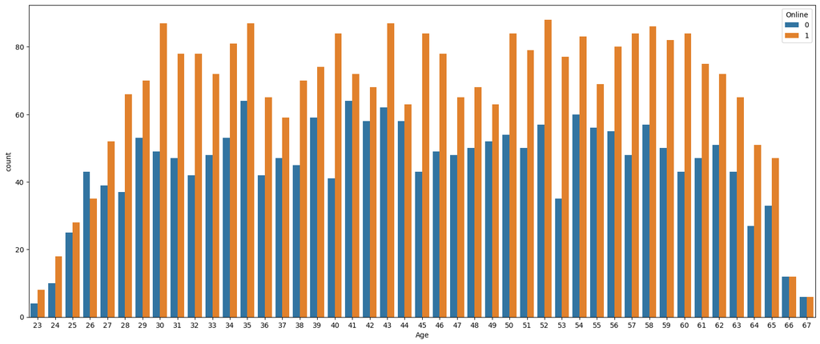

```python
# Exploring the correlation between Online and Age

plt.figure(figsize=(20,8))
sns.countplot(data=df,x='Age',hue='Online')
plt.show()
```

- As seen in the above count plot, the distribution between the customers who use Internet banking facilities and their age is surprisingly normal, I would have believed that the older the customers the less prone they are to use an Internet banking facility, but that is not the case.

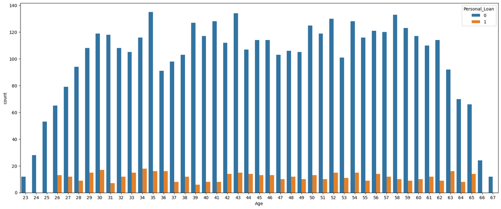

```python
# Exploring the relationship between Age & Personal Loan

plt.figure(figsize=(20,8))
sns.countplot(data=df,x='Age',hue='Personal_Loan')
plt.show()
```

- As seen in the count plot above the data is normally distributed, there is no presence of any skewness or outliers.
- Although, the amount of customers who had accepted a personal loan offer to those who didn't across all ages in the data is quite drastic.

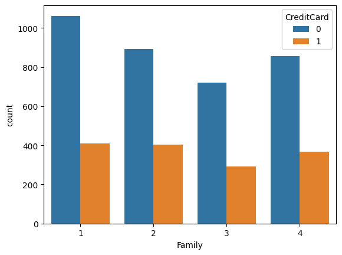

```python
# Analyzing the relationship between Family Size and Credit Card Usage

sns.countplot(data=df,x='Family',hue='CreditCard')
plt.show()
```

- In the above plot, from family sizes 1 through 4, there is almost a double in the amount of those who do not use a credit card issued by any other bank compared to the families that did.
- This shows that the families that were partaken in the data are loyal to AllLife Bank.

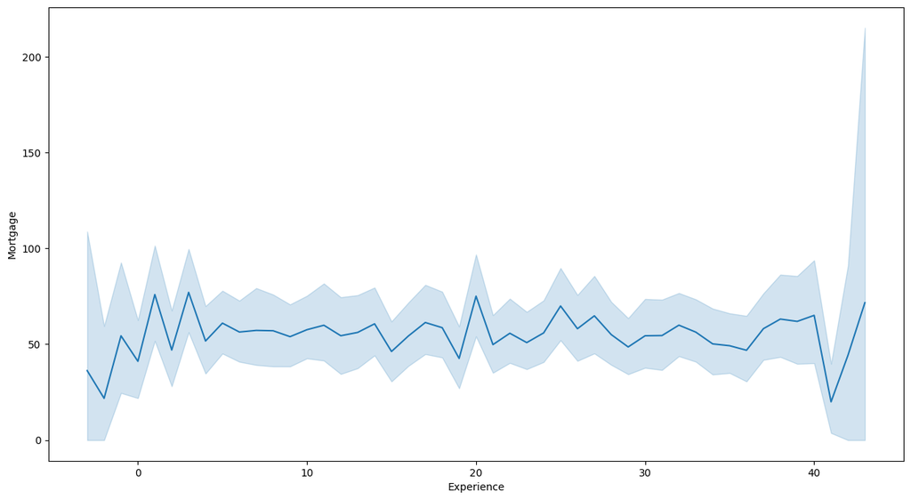

```python
# Investigating the realtionship between Experience and Mortgage Value

plt.figure(figsize=(15,8))
sns.lineplot(data=df,x='Experience',y='Mortgage')
plt.show()
```

- From this line plot above, we can observe that there is not any significant change happening as the years of professional experience increase.
- Therefore concluding that the correlation between these two columns is not as notable as expected. This could also be due to not enough houses having mortgages.

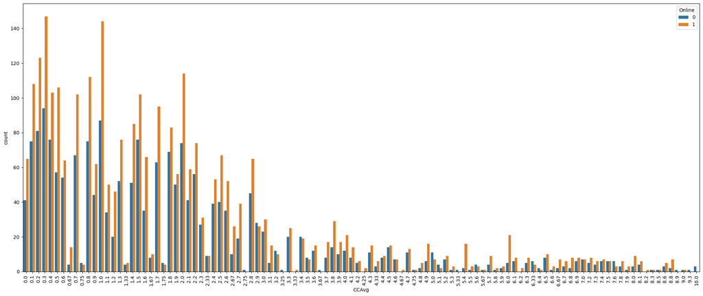

```python
# Depicting the relationship between CCAvg & Online

plt.figure(figsize=(25,10))
sns.countplot(data=df,x='CCAvg',hue='Online')
plt.xticks(rotation=90) # Rotate x-axis labels by 90 degrees
plt.show()
```

- In the count plot, it seems to be right-skewed meaning that there is a more significant amount of customers who spend less whilst utilizing an internet banking facility.
- Therefore the more the average customer spends on their credit card per month, the less the amount of customers who use the internet banking facility.

## Data Preprocessing

- Missing value treatment
- Feature engineering (if needed)
- Outlier detection and treatment (if needed)
- Preparing data for modeling
- Any other preprocessing steps (if needed)

### Missing Value Treatment

```python
# Count the percentage of missing values (if any) in each column

pd.DataFrame({'Count':df.isnull().sum()[df.isnull().sum()>0],'Percentage':(df.isnull().sum()[df.isnull().sum()>0]/df.shape[0])*100})
```

|  | Count | Percentage |
| --- | --- | --- |

- As seen in the above table, there are no columns with any missing values therefore the table is empty with no rows or columns.

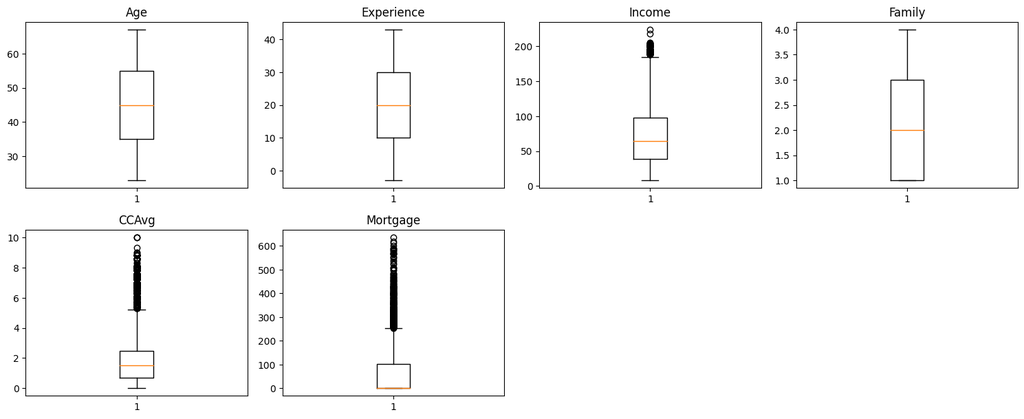

```python
# Visualizing the outliers in all the numerical columns present in the data

numeric_columns = ['Age', 'Experience', 'Income', 'Family', 'CCAvg', 'Mortgage']
plt.figure(figsize=(15, 12))

for i, variable in enumerate(numeric_columns):
    plt.subplot(4, 4, i + 1)
    plt.boxplot(df[variable], whis=1.5)
    plt.tight_layout()
    plt.title(variable)

plt.show()
```

- We can observe that 3 out of the 6 numerical columns contain outliers in them.

**Analyze the numerical columns to see if the values are considered outliers or not.**

- Income - The outliers in this column can be considered normal data because a customer's annual income can be more than about 180 thousand dollars, that is something that isn't unrealistic.
- CCAvg - The customer's average spending on credit cards per month depends upon various factors. For instance, the type of job that individual is working, obviously the majority of customers have a credit card spending average of less than 3 thousand dollars per month, but again it could be considered as genuine data.
- Mortgage - The value of the customer's house mortgage also varies in many elements as well. The customer's house location, for instance, can contribute to the mortgage price, the prices could also change from time to time. Additionally, the outliers are outliers due to there being a significant amount of customers who do not have mortgages for their houses to those who do.

Therefore, the outliers present in the data are not considered outliers and do not need to be treated.

### Data Preperation for Modeling

```python
# Looking at the first 5 rows of the data.

df.head()
```

|  | ID | Age | Experience | Income | ZIPCode | Family | CCAvg | Education | Mortgage | Personal_Loan | Securities_Account | CD_Account | Online | CreditCard |
| --- | --- | --- | --- | --- | --- | --- | --- | --- | --- | --- | --- | --- | --- | --- |
| 0 | 1 | 25 | 1 | 49 | 91107 | 4 | 1.6 | 1 | 0 | 0 | 1 | 0 | 0 | 0 |
| 1 | 2 | 45 | 19 | 34 | 90089 | 3 | 1.5 | 1 | 0 | 0 | 1 | 0 | 0 | 0 |
| 2 | 3 | 39 | 15 | 11 | 94720 | 1 | 1.0 | 1 | 0 | 0 | 0 | 0 | 0 | 0 |
| 3 | 4 | 35 | 9 | 100 | 94112 | 1 | 2.7 | 2 | 0 | 0 | 0 | 0 | 0 | 0 |
| 4 | 5 | 35 | 8 | 45 | 91330 | 4 | 1.0 | 2 | 0 | 0 | 0 | 0 | 0 | 1 |

- From looking at the data, we can create a dummy variable for the Education column to visualize the classifications for each education level in separate columns.

```python
# First convert education level 1 to Undergrad, level 2 to Graduate, level 3 to Professional
df['Education'] = df['Education'].replace({1:'Undergrad',2:'Graduate',3:'Professional'})

# Create dummy variables for the Eduaction column

df = pd.get_dummies(df, columns=['Education'])
df.head()
```

|  | ID | Age | Experience | Income | ZIPCode | Family | CCAvg | Mortgage | Personal_Loan | Securities_Account | CD_Account | Online | CreditCard | Education_Graduate | Education_Professional | Education_Undergrad |
| --- | --- | --- | --- | --- | --- | --- | --- | --- | --- | --- | --- | --- | --- | --- | --- | --- |
| 0 | 1 | 25 | 1 | 49 | 91107 | 4 | 1.6 | 0 | 0 | 1 | 0 | 0 | 0 | False | False | True |
| 1 | 2 | 45 | 19 | 34 | 90089 | 3 | 1.5 | 0 | 0 | 1 | 0 | 0 | 0 | False | False | True |
| 2 | 3 | 39 | 15 | 11 | 94720 | 1 | 1.0 | 0 | 0 | 0 | 0 | 0 | 0 | False | False | True |
| 3 | 4 | 35 | 9 | 100 | 94112 | 1 | 2.7 | 0 | 0 | 0 | 0 | 0 | 0 | True | False | False |
| 4 | 5 | 35 | 8 | 45 | 91330 | 4 | 1.0 | 0 | 0 | 0 | 0 | 0 | 1 | True | False | False |

```python
# Currently the dummy variables are True and False, we need to make it 1s and 0s.

for col in ["Education_Graduate", "Education_Professional", "Education_Undergrad"]:
  df[col] = df[col].astype(int)
```

```python
df.head()
```

|  | ID | Age | Experience | Income | ZIPCode | Family | CCAvg | Mortgage | Personal_Loan | Securities_Account | CD_Account | Online | CreditCard | Education_Graduate | Education_Professional | Education_Undergrad |
| --- | --- | --- | --- | --- | --- | --- | --- | --- | --- | --- | --- | --- | --- | --- | --- | --- |
| 0 | 1 | 25 | 1 | 49 | 91107 | 4 | 1.6 | 0 | 0 | 1 | 0 | 0 | 0 | 0 | 0 | 1 |
| 1 | 2 | 45 | 19 | 34 | 90089 | 3 | 1.5 | 0 | 0 | 1 | 0 | 0 | 0 | 0 | 0 | 1 |
| 2 | 3 | 39 | 15 | 11 | 94720 | 1 | 1.0 | 0 | 0 | 0 | 0 | 0 | 0 | 0 | 0 | 1 |
| 3 | 4 | 35 | 9 | 100 | 94112 | 1 | 2.7 | 0 | 0 | 0 | 0 | 0 | 0 | 1 | 0 | 0 |
| 4 | 5 | 35 | 8 | 45 | 91330 | 4 | 1.0 | 0 | 0 | 0 | 0 | 0 | 1 | 1 | 0 | 0 |

```python
# Split the Data

X = df.drop(columns=['ID', 'Personal_Loan', 'ZIPCode'])
y = df['Personal_Loan']
```

```python
# Split X and y into training and test set in 70:30 ratio

X_train, X_test, y_train, y_test = train_test_split(X, y, test_size=0.30, random_state=1)
```

```python
# Fit Linear Model

import numpy as np
from sklearn.linear_model import LinearRegression
import pandas as pd
import matplotlib.pyplot as plt
%matplotlib inline
import seaborn as sns
from sklearn.model_selection import train_test_split # Sklearn package's randomized data splitting function


regression_model = LinearRegression()
regression_model.fit(X_train, y_train)
```

```
LinearRegression()
```

```python
# Finding the coefficients for each variable and the intercept

for idx, col_name in enumerate(X_train.columns):
    print("The coefficient for {} is {}".format(col_name, regression_model.coef_[idx]))
```

```
The coefficient for Age is -0.005830340667264938
The coefficient for Experience is 0.0061262713120217235
The coefficient for Income is 0.002865613233001863
The coefficient for Family is 0.030120456156665
The coefficient for CCAvg is 0.017078887769683835
The coefficient for Mortgage is 9.202942920009786e-05
The coefficient for Securities_Account is -0.06919883202815111
The coefficient for CD_Account is 0.32522827129942355
The coefficient for Online is -0.02580536206404267
The coefficient for CreditCard is -0.0438562200155962
The coefficient for Education_Graduate is 0.04436230205329969
The coefficient for Education_Professional is 0.0510163082973728
The coefficient for Education_Undergrad is -0.09537861035067265
```

```python
# Access the intercept directly as a scalar
intercept = regression_model.intercept_
print("The intercept for the model is {}".format(intercept))
```

```
The intercept for the model is -0.0587430650011478
```

```python
# Finding the score (R^2) for in-sample
regression_model.score(X_train, y_train)
```

```
0.40176895932889156
```

```python
# out of sample score (R^2)

regression_model.score(X_test, y_test)
```

```
0.3818473592515367
```

## Model Building

### Model Evaluation Criterion

- Since the objective is a binary prediction of whether or not a liability customer will buy personal loans, to understand which customer attributes are more significant in driving purchases, and to identify which segment of customers to target more, we will choose **Accuracy**, **Precision**, **Recall**, **F1 Score** and the **Confusion Matrix** as the evaluation criteria.

### Model Building

```python
import pandas as pd
import numpy as np
from sklearn import metrics
import matplotlib.pyplot as plt
%matplotlib inline
import seaborn as sns
from sklearn.model_selection import train_test_split
from sklearn.tree import DecisionTreeClassifier
from sklearn import tree
from sklearn.metrics import accuracy_score, precision_score, recall_score, f1_score, confusion_matrix, classification_report
```

- We will utilize the DecisionTreeClassifier function which is imported above, as well as using default 'gini' criteria to split the data.

```python
dTree = DecisionTreeClassifier(criterion = 'gini', random_state=1)
dTree.fit(X_train, y_train)
```

```
DecisionTreeClassifier(random_state=1)
```

```python
# Scoring the Decision Tree

print("Accuracy on the Training Set:",dTree.score(X_train, y_train))
print("Accuracy on the Test Set:    ",dTree.score(X_test, y_test))
```

```
Accuracy on the Training Set: 1.0
Accuracy on the Test Set:     0.98
```

```python
# Checking number of positives

y.value_counts(1)
```

```
Personal_Loan
0    0.904
1    0.096
Name: proportion, dtype: float64
```

- The ratio of positives to negatives is 1 to 9, meaning for every customer who accepts the personal loan, approximately 9 customers do not accept it.

```python
## Function to create confusion matrix
def make_confusion_matrix(model,y_actual,labels=[1, 0]):

    y_predict = model.predict(X_test)
    cm=metrics.confusion_matrix( y_actual, y_predict, labels=[0, 1])
    df_cm = pd.DataFrame(cm, index = [i for i in ["Actual - No","Actual - Yes"]],
                  columns = [i for i in ['Predicted - No','Predicted - Yes']])
    group_counts = ["{0:0.0f}".format(value) for value in
                cm.flatten()]
    group_percentages = ["{0:.2%}".format(value) for value in
                         cm.flatten()/np.sum(cm)]
    labels = [f"{v1}\n{v2}" for v1, v2 in
              zip(group_counts,group_percentages)]
    labels = np.asarray(labels).reshape(2,2)
    plt.figure(figsize = (10,7))
    sns.heatmap(df_cm, annot=labels,fmt='')
    plt.ylabel('True label')
    plt.xlabel('Predicted label')
```

```python
##  Function to calculate recall score
def get_recall_score(model):
    '''
    model : classifier to predict values of X

    '''
    pred_train = model.predict(X_train)
    pred_test = model.predict(X_test)
    print("Recall on training set : ",metrics.recall_score(y_train,pred_train))
    print("Recall on test set : ",metrics.recall_score(y_test,pred_test))
```

```python
# Making predictions

y_pred = dTree.predict(X_test)
```

```python
# Evaluating the model

accuracy = accuracy_score(y_test, y_pred)
precision = precision_score(y_test, y_pred)
f1 = f1_score(y_test, y_pred)
conf_matrix = confusion_matrix(y_test, y_pred)
class_report = classification_report(y_test, y_pred)
```

```python
# Printing the evaluation

print(f"Accuracy: {accuracy}")
print(f"Precision: {precision}")
print(f"F1 Score: {f1}")
print("Confusion Matrix:")
print(conf_matrix)
print("Classification Report:")
print(class_report)
```

```
Accuracy: 0.98
Precision: 0.9103448275862069
F1 Score: 0.8979591836734694
Confusion Matrix:
[[1338   13]
 [  17  132]]
Classification Report:
              precision    recall  f1-score   support

           0       0.99      0.99      0.99      1351
           1       0.91      0.89      0.90       149

    accuracy                           0.98      1500
   macro avg       0.95      0.94      0.94      1500
weighted avg       0.98      0.98      0.98      1500
```

From the print statements, we can observe:

- The accuracy (which measures the overall correctness of the model) resulted at 98% which is a good score and suggests that the model is performing well overall.
- The precision ended up at 91%, meaning that when the model predicts a customer to buy a personal loan, it is correct 91% of the time. This is important for minimizing false positives, which means predicting a customer will buy a loan when they end up not buying.
- For the recall, the score ended up being 89%, this is a crucial score that must be a high enough percentage for identifying as many potential buyers as possible, and to make sure none of them are missed.
- In F1 Score resulted at 90%, which indicates that the model maintains a good trade-off between the precision and the recall, it also shows the model's robustness in identifying the customers who bought the loans.

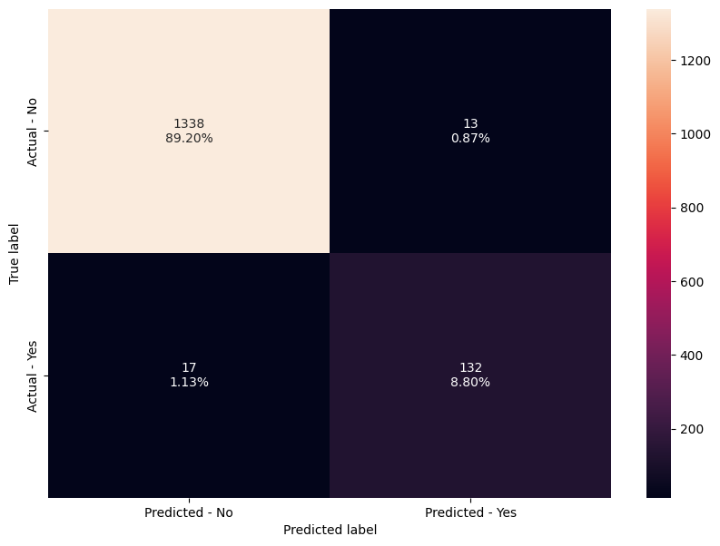

```python
make_confusion_matrix(dTree,y_test)
```

```python
# Retrieving the recall score on the training and the test set
get_recall_score(dTree)
```

```
Recall on training set :  1.0
Recall on test set :  0.8859060402684564
```

From the Confusion Matrix, as seen above, we can observe:

- There are 1338 customers correctly predicted not to buy a loan.
- 13 Customers who had incorrectly predicted to buy a loan.
- 17 Customers who had actually bought a loan but the model incorrectly predicted not to buy a loan.
- There are 132 customers correctly predicted to buy a loan.

```python
print(class_report)
```

```
              precision    recall  f1-score   support

           0       0.99      0.99      0.99      1351
           1       0.91      0.89      0.90       149

    accuracy                           0.98      1500
   macro avg       0.95      0.94      0.94      1500
weighted avg       0.98      0.98      0.98      1500
```

From the classification report, we can observe that:

- Class 0 (Non-loan buyers):
  - The precision, recall, and F1 scores are all 0.99, which indicates that the model performs exceptionally well in identifying those customers who did not accept the personal loan offer.
- Class 1 (Loan buyers):
  - the precision score being 0.91, the recall score of 0.89, and the F1 score of 0.90, suggest that the model is very effective in identifying buyers, although there is a slight trade-off between precision and the recall scores.

### Visualizng the Decision Tree

```python
# Printing the customer attributes

cust_attributes = list(X.columns)
print(cust_attributes)
```

```
['Age', 'Experience', 'Income', 'Family', 'CCAvg', 'Mortgage', 'Securities_Account', 'CD_Account', 'Online', 'CreditCard', 'Education_Graduate', 'Education_Professional', 'Education_Undergrad']
```

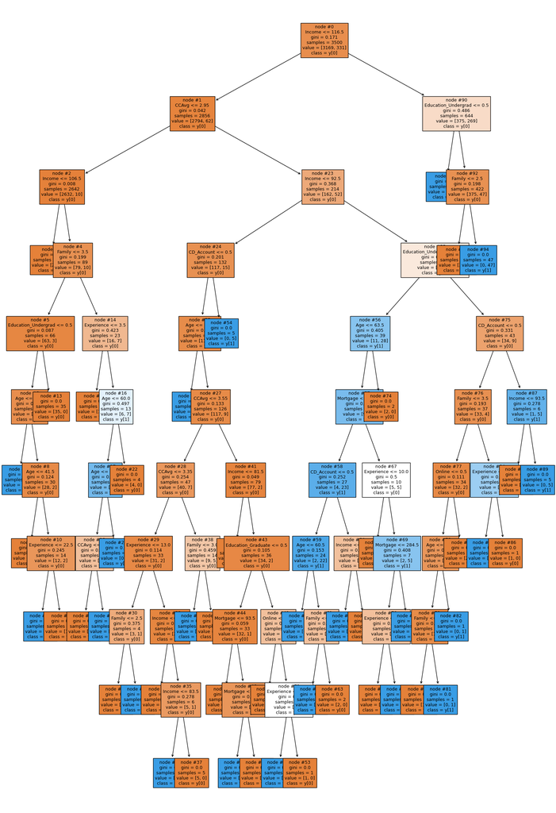

```python
plt.figure(figsize=(20,30))
tree.plot_tree(dTree,feature_names=cust_attributes,filled=True,fontsize=9,node_ids=True,class_names=True)
plt.show()
```

```python
# Text report displaying the rules of a decision tree

print(tree.export_text(dTree,feature_names=cust_attributes,show_weights=True))
```

```
|--- Income <= 116.50
|   |--- CCAvg <= 2.95
|   |   |--- Income <= 106.50
|   |   |   |--- weights: [2553.00, 0.00] class: 0
|   |   |--- Income >  106.50
|   |   |   |--- Family <= 3.50
|   |   |   |   |--- Education_Undergrad <= 0.50
|   |   |   |   |   |--- Age <= 28.50
|   |   |   |   |   |   |--- weights: [0.00, 1.00] class: 1
|   |   |   |   |   |--- Age >  28.50
|   |   |   |   |   |   |--- Age <= 41.50
|   |   |   |   |   |   |   |--- weights: [16.00, 0.00] class: 0
|   |   |   |   |   |   |--- Age >  41.50
|   |   |   |   |   |   |   |--- Experience <= 22.50
|   |   |   |   |   |   |   |   |--- weights: [0.00, 2.00] class: 1
|   |   |   |   |   |   |   |--- Experience >  22.50
|   |   |   |   |   |   |   |   |--- weights: [12.00, 0.00] class: 0
|   |   |   |   |--- Education_Undergrad >  0.50
|   |   |   |   |   |--- weights: [35.00, 0.00] class: 0
|   |   |   |--- Family >  3.50
|   |   |   |   |--- Experience <= 3.50
|   |   |   |   |   |--- weights: [10.00, 0.00] class: 0
|   |   |   |   |--- Experience >  3.50
|   |   |   |   |   |--- Age <= 60.00
|   |   |   |   |   |   |--- Age <= 32.50
|   |   |   |   |   |   |   |--- CCAvg <= 2.35
|   |   |   |   |   |   |   |   |--- weights: [2.00, 0.00] class: 0
|   |   |   |   |   |   |   |--- CCAvg >  2.35
|   |   |   |   |   |   |   |   |--- weights: [0.00, 1.00] class: 1
|   |   |   |   |   |   |--- Age >  32.50
|   |   |   |   |   |   |   |--- weights: [0.00, 6.00] class: 1
|   |   |   |   |   |--- Age >  60.00
|   |   |   |   |   |   |--- weights: [4.00, 0.00] class: 0
|   |--- CCAvg >  2.95
|   |   |--- Income <= 92.50
|   |   |   |--- CD_Account <= 0.50
|   |   |   |   |--- Age <= 26.50
|   |   |   |   |   |--- weights: [0.00, 1.00] class: 1
|   |   |   |   |--- Age >  26.50
|   |   |   |   |   |--- CCAvg <= 3.55
```

[output cut: 87 more lines]

```
|   |   |   |   |   |   |--- Experience >  21.50
|   |   |   |   |   |   |   |--- weights: [1.00, 0.00] class: 0
|   |   |   |   |--- CD_Account >  0.50
|   |   |   |   |   |--- Income <= 93.50
|   |   |   |   |   |   |--- weights: [1.00, 0.00] class: 0
|   |   |   |   |   |--- Income >  93.50
|   |   |   |   |   |   |--- weights: [0.00, 5.00] class: 1
|--- Income >  116.50
|   |--- Education_Undergrad <= 0.50
|   |   |--- weights: [0.00, 222.00] class: 1
|   |--- Education_Undergrad >  0.50
|   |   |--- Family <= 2.50
|   |   |   |--- weights: [375.00, 0.00] class: 0
|   |   |--- Family >  2.50
|   |   |   |--- weights: [0.00, 47.00] class: 1
```

- As seen in the above textual representation of the decision tree, some could view this as a better method of easily understanding the information in a decision tree rather than looking at the cramped-up visual depiction.

```python
# Text version for the important features in the decision tree

print (pd.DataFrame(dTree.feature_importances_, columns = ["Importance"], index = X_train.columns).sort_values(by = 'Importance', ascending = False))
```

```
                        Importance
Education_Undergrad       0.401465
Income                    0.306244
Family                    0.165104
CCAvg                     0.044408
CD_Account                0.025711
Age                       0.024890
Experience                0.021425
Mortgage                  0.008792
Online                    0.001117
Education_Graduate        0.000843
Securities_Account        0.000000
CreditCard                0.000000
Education_Professional    0.000000
```

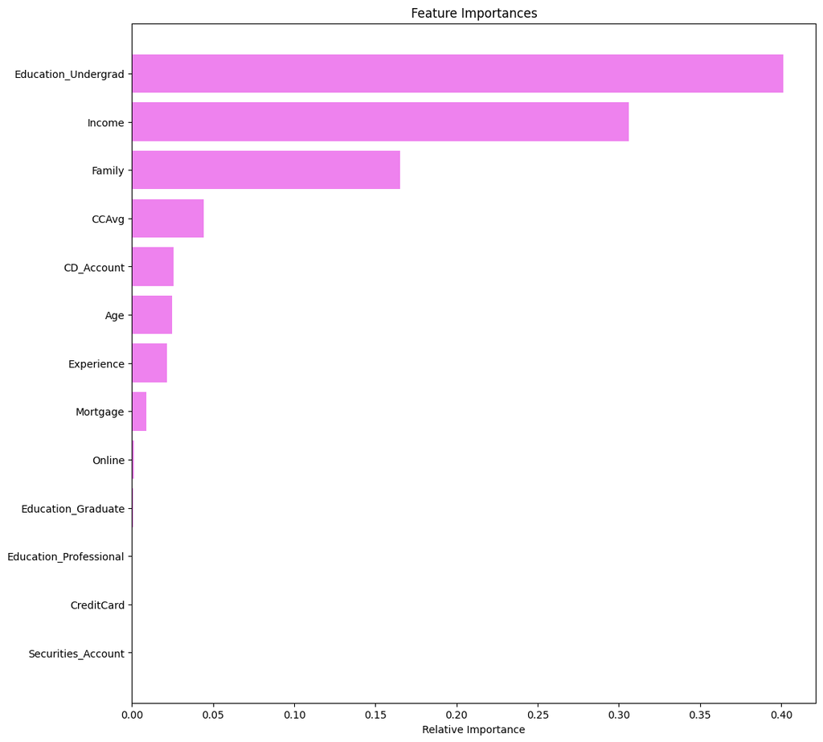

```python
# Graphical figure of the important features

importances = dTree.feature_importances_
indices = np.argsort(importances)

plt.figure(figsize=(12,12))
plt.title('Feature Importances')
plt.barh(range(len(indices)), importances[indices], color='violet', align='center')
plt.yticks(range(len(indices)), [cust_attributes[i] for i in indices])
plt.xlabel('Relative Importance')
plt.show()
```

As you can see from the bar graph above, the Undergrad Education attribute is the most important variable for predicting a liability customer will buy personal loans. Following that, the customer's annual income and their family size are the runner-ups on the relative importance.